# NYC CitiBike Trip Exploration [2] - Data Exploration

This is the second part of NYC CitiBike Trip Exploration. We will focus on data exploration with the [System Data](https://www.citibikenyc.com/system-data).

[interactive chart not shown]

## Data preparation

The libraries used are listed:

```r
library(plyr)  # require rbind.fill
library(stringr)
library(dplyr)
library(dygraphs)
library(xts)
library(leaflet) # leaflet from rstudio
library(igraph)
```

Due to large volume, we chunk the data and select only the data of 2014.

```r
db_bike <- src_sqlite("../input/rds/dt_bike_clean.sqlite3")

# get dt_bike and get year ==2014
dt_bike_sql <- tbl(db_bike, from="dt_bike") %>% filter(year==2014)
dt_bike <- collect(dt_bike_sql)
```

## Trip per day

We now visualize the trip count per day versus the duration and the distance of the trip. The values in mean & median are displayed in order to avoid the influence of extreme value.

```r
dt_plot <- dt_bike %>% group_by(year, month, mday) %>%
  summarise(
    trip_count=n(),
    total_duration=sum(tripduration),
    mean_duration=mean(tripduration),
    median_duration=median(as.numeric(tripduration)),
    total_distance=sum(tripdistance),
    mean_distance=mean(tripdistance),
    median_distance=median(tripdistance),
    mean_speed=mean(tripdistance/tripduration)
    ) %>%
  mutate(date=as.POSIXct(paste(year, month, mday, sep="-"))) %>%
  ungroup() %>%
  select(-year, -month, -mday)
# duration
dt_xts <- as.xts(dt_plot[, c("trip_count", "mean_duration", "median_duration")], order.by = dt_plot$date)
dygraph(dt_xts, main="Trip duration per day") %>% dySeries("median_duration", axis="y2") %>% dySeries("mean_duration", axis="y2")
```

[interactive chart not shown]

```r
# distance
dt_xts <- as.xts(dt_plot[, c("trip_count", "mean_distance", "median_distance")], order.by = dt_plot$date)
dygraph(dt_xts, main="Trip distance per day") %>% dySeries("median_distance", axis="y2") %>% dySeries("mean_distance", axis="y2")
```

[interactive chart not shown]

We can find that in general, we have more trips in summer and less trips in winter. And in winter, we have some extreme values, these could be explained by weather condition (to be verified).

## Trip per weekday

We now visualize the trip count per weekday (i.e. monday, tuesday, ..., sunday) versus the duration and the distance of the trip. The values in mean & median are displayed in order to avoid the influence of extreme value.

1 is sunday, 2 is monday, ..., 7 is saturday.

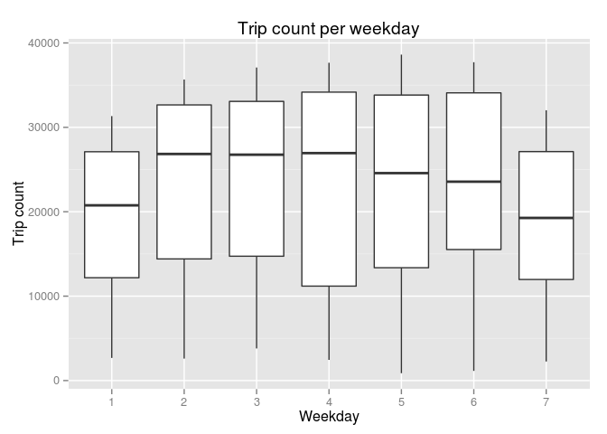

```r
dt_plot <- dt_bike %>% group_by(year, month, mday, wday) %>%
  summarise(
    trip_count=n(),
    total_duration=sum(tripduration),
    mean_duration=mean(tripduration),
    median_duration=median(as.numeric(tripduration)),
    total_distance=sum(tripdistance),
    mean_distance=mean(tripdistance),
    median_distance=median(tripdistance),
    mean_speed=mean(tripdistance/tripduration)
  )

with(dt_plot, ggplot2::qplot(factor(wday), trip_count,
  geom="boxplot", main="Trip count per weekday", xlab="Weekday", ylab="Trip count"))
```

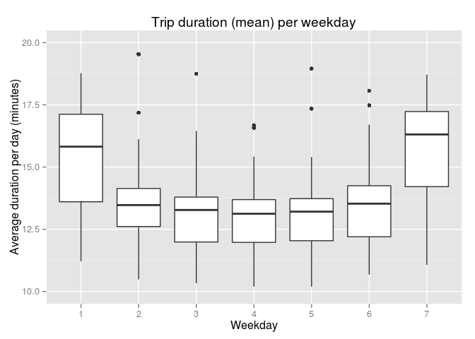

```r
with(dt_plot, ggplot2::qplot(factor(wday), mean_duration/60,
  geom="boxplot", main="Trip duration (mean) per weekday", xlab="Weekday", ylab="Average duration per day (minutes)", ylim=c(10,20)))
```

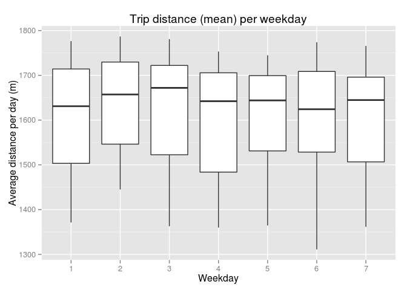

```r
with(dt_plot, ggplot2::qplot(factor(wday), mean_distance,
  geom="boxplot", main="Trip distance (mean) per weekday", xlab="Weekday", ylab="Average distance per day (m)"))
```

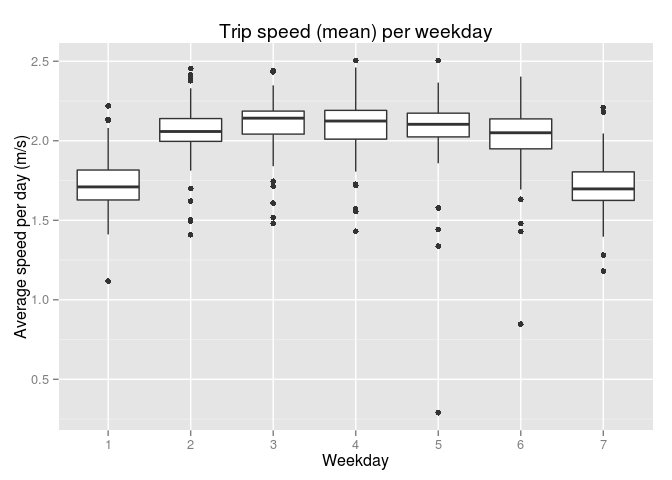

```r
with(dt_plot, ggplot2::qplot(factor(wday), mean_distance/mean_duration,
  geom="boxplot", main="Trip speed (mean) per weekday", xlab="Weekday", ylab="Average speed per day (m/s)"))
```

Some interesting thing could be found:

- The usage of citibike is less frequent at the weekend
- The bike riding is in low speed at the weekend

## Trip per hour

We now visualize the trip count per hour versus the duration and the distance of the trip. The values in mean & median are displayed in order to avoid the influence of extreme value.

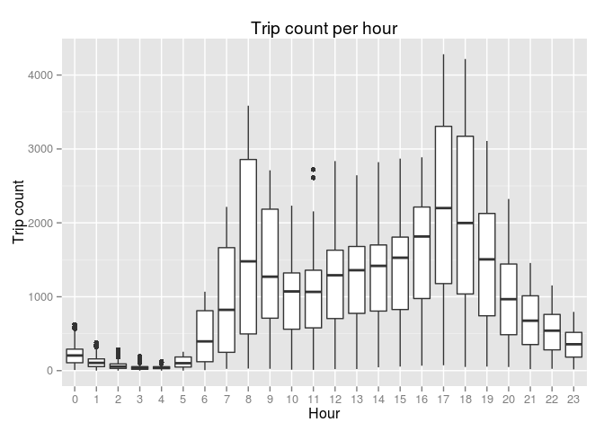

```r
dt_plot <- dt_bike %>% group_by(year, month, mday, hour) %>%
  summarise(
    trip_count=n(),
    total_duration=sum(tripduration),
    mean_duration=mean(tripduration),
    median_duration=median(as.numeric(tripduration)),
    total_distance=sum(tripdistance),
    mean_distance=mean(tripdistance),
    median_distance=median(tripdistance),
    mean_speed=mean(tripdistance/tripduration)
  )

with(dt_plot, ggplot2::qplot(factor(hour), trip_count,
  geom="boxplot", main="Trip count per hour", xlab="Hour", ylab="Trip count"))
```

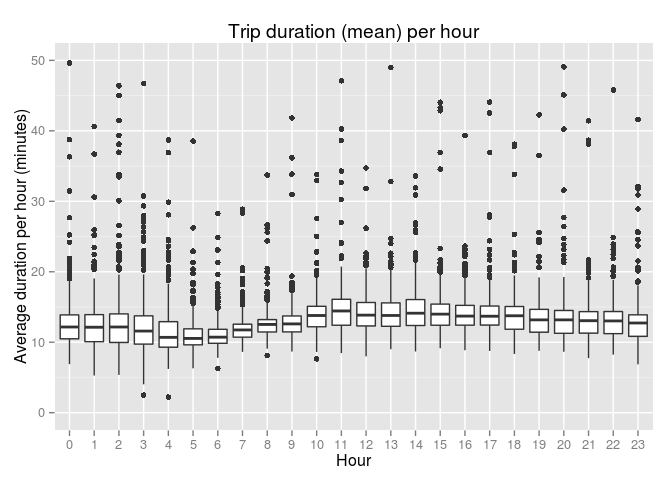

```r
with(dt_plot, ggplot2::qplot(factor(hour), mean_duration/60,
  geom="boxplot", main="Trip duration (mean) per hour", xlab="Hour", ylab="Average duration per hour (minutes)", ylim=c(0,50)))
```

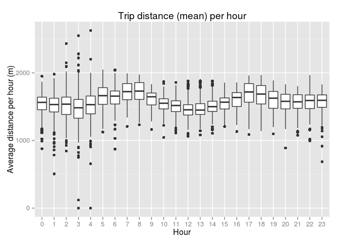

```r
with(dt_plot, ggplot2::qplot(factor(hour), mean_distance,
  geom="boxplot", main="Trip distance (mean) per hour", xlab="Hour", ylab="Average distance per hour (m)"))
```

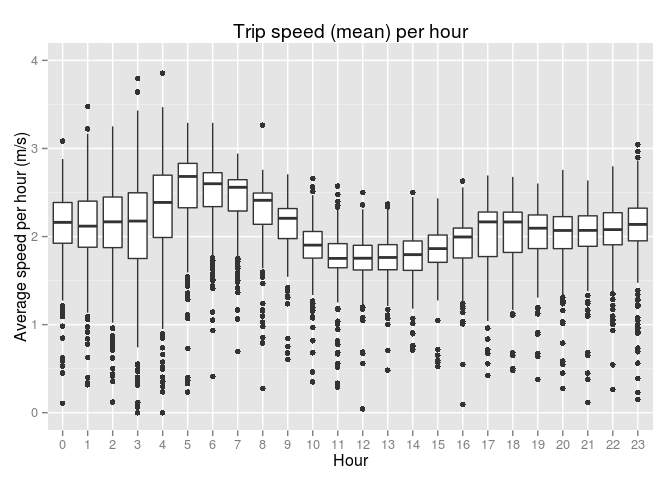

```r
with(dt_plot, ggplot2::qplot(factor(hour), mean_distance/mean_duration,
  geom="boxplot", main="Trip speed (mean) per hour", xlab="Hour", ylab="Average speed per hour (m/s)", ylim=c(0,4)))
```

## Usertype

There exists two types of contract: Customer & Subscriber. We cannot distinguish the type of customer: 24H pass or 7-day pass.

```r
## usertype
with(dt_bike,round(prop.table(table(usertype)), 4))
```

```
## usertype
##   Customer Subscriber
##     0.0982     0.9018
```

```r
## trip count by usertype
dt_plot <- dt_bike %>% group_by(usertype, year, month, mday) %>% summarise(trip_count=n()) %>%
  tidyr::spread(usertype,trip_count) %>% mutate(date=as.POSIXct(paste(year, month, mday, sep="-"))) %>%
  ungroup() %>% select(-year, -month, -mday)

dt_xts <- xts(dt_plot[,1:2], order.by = dt_plot$date)
dygraph(dt_xts, main="Trip count by usertype", group="trip_usertype")
```

[interactive chart not shown]

```r
## trip duration by usertype
dt_plot <- dt_bike %>% group_by(usertype, year, month, mday) %>% summarise(median_duration=median(tripduration)) %>%
  tidyr::spread(usertype,median_duration) %>% mutate(date=as.POSIXct(paste(year, month, mday, sep="-"))) %>%
  ungroup() %>% select(-year, -month, -mday)

dt_xts <- xts(dt_plot[,1:2], order.by = dt_plot$date)
dygraph(dt_xts, main="Trip duration by usertype [median]", group="trip_usertype")
```

[interactive chart not shown]

```r
## trip distance by usertype
dt_plot <- dt_bike %>% group_by(usertype, year, month, mday) %>% summarise(median_distance=median(tripdistance)) %>%
  tidyr::spread(usertype,median_distance) %>% mutate(date=as.POSIXct(paste(year, month, mday, sep="-"))) %>%
  ungroup() %>% select(-year, -month, -mday)

dt_xts <- xts(dt_plot[,1:2], order.by = dt_plot$date)
dygraph(dt_xts, main="Trip distance by usertype [median]", group="trip_usertype")
```

[interactive chart not shown]

## Focus on subscriber

Next, we will focus on two variables available for subscriber: Age & Gender.

### Gender (Subscriber only)

Here is the decode:

- 0: Not available (mostly for Customer)
- 1: Male
- 2: Female

N.B. there is no individual gender. Gender is recorded per trip.

```r
# with(dt_bike, {table(usertype, gender)})

# trip count
dt_plot <- dt_bike %>% filter(usertype=="Subscriber") %>% group_by(gender,year, month, mday) %>% summarise(trip_count=n()) %>%
  tidyr::spread(gender,trip_count) %>% mutate(date=as.POSIXct(paste(year, month, mday, sep="-"))) %>%
  ungroup() %>% select(-year, -month, -mday)

dt_xts <- xts(dt_plot[,2:3], order.by = dt_plot$date)
dygraph(dt_xts, main="Trip count by gender", group="trip_gender")
```

[interactive chart not shown]

```r
# trip duration
dt_plot <- dt_bike %>% filter(usertype=="Subscriber") %>% group_by(gender,year, month, mday) %>% summarise(median_duration=median(as.numeric(tripduration))) %>%
  tidyr::spread(gender,median_duration) %>% mutate(date=as.POSIXct(paste(year, month, mday, sep="-"))) %>%
  ungroup() %>% select(-year, -month, -mday)

dt_xts <- xts(dt_plot[,2:3], order.by = dt_plot$date)
dygraph(dt_xts, main="Trip duration by gender[median]", group="trip_gender")
```

[interactive chart not shown]

```r
# trip distance
dt_plot <- dt_bike %>% filter(usertype=="Subscriber") %>% group_by(gender,year, month, mday) %>% summarise(median_distance=median(as.numeric(tripdistance))) %>%
  tidyr::spread(gender,median_distance) %>% mutate(date=as.POSIXct(paste(year, month, mday, sep="-"))) %>%
  ungroup() %>% select(-year, -month, -mday)

dt_xts <- xts(dt_plot[,2:3], order.by = dt_plot$date)
dygraph(dt_xts, main="Trip distance by gender[median]", group="trip_gender")
```

[interactive chart not shown]

### Age (Subscriber only)

Some outliers exist, the data records age > 85, this is not true, and we have just recoded them as NA. Some interesting insight could be found in each age group.

N.B. there is no individual age. Age is recorded per trip.

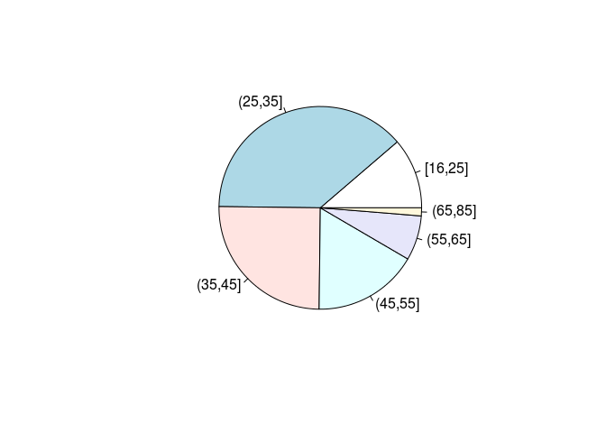

```r
# with(dt_bike, {table(usertype, age)})
dt_bike$age_cut <- cut(dt_bike$age, c(16, 25, 35, 45, 55, 65, 85), include.lowest = TRUE)
pie(table(dt_bike$age_cut))
```

```r
dt_bike$age_cut_char <- as.character(dt_bike$age_cut)
# trip count # to be cross with number of subscription per age, no data available
dt_plot <- dt_bike %>% filter(usertype=="Subscriber" & age_cut_char!="") %>% group_by(age_cut_char,year, month, mday) %>% summarise(trip_count=n()) %>%
  tidyr::spread(age_cut_char,trip_count) %>%
  mutate(date=as.POSIXct(paste(year, month, mday, sep="-"))) %>%
  ungroup() %>% select(-year, -month, -mday)

dt_xts <- xts(dt_plot[,1:6], order.by = dt_plot$date)
dygraph(dt_xts, main="Trip count by age", group="trip_age")
```

[interactive chart not shown]

```r
# trip duration
dt_plot <- dt_bike %>%
  filter(usertype=="Subscriber" & age_cut_char!="") %>%
  group_by(age_cut_char,year, month, mday) %>% summarise(median_duration=median(as.numeric(tripduration))) %>%
  tidyr::spread(age_cut_char,median_duration) %>% mutate(date=as.POSIXct(paste(year, month, mday, sep="-"))) %>%
  ungroup() %>% select(-year, -month, -mday)

dt_xts <- xts(dt_plot[,1:6], order.by = dt_plot$date)
dygraph(dt_xts, main="Trip duration by age [median]", group="trip_age")
```

[interactive chart not shown]

```r
# trip distance
dt_plot <- dt_bike %>%
  filter(usertype=="Subscriber" & age_cut_char!="") %>%
  group_by(age_cut_char,year, month, mday) %>%
  summarise(median_distance=median(as.numeric(tripdistance))) %>%
  tidyr::spread(age_cut_char,median_distance) %>%
  mutate(date=as.POSIXct(paste(year, month, mday, sep="-"))) %>%
  ungroup() %>% select(-year, -month, -mday)

dt_xts <- xts(dt_plot[,1:6], order.by = dt_plot$date)
dygraph(dt_xts, main="Trip distance by age [median]", group="trip_gender")
```

[interactive chart not shown]

## Vision Bike

Let's see how many bikes are operational per day, and what's the bike rotation.

```r
# how many bikes operational?
dt_plot <- dt_bike %>% group_by(year, month, mday) %>%
  summarise(bike_op=n_distinct(bikeid)) %>%
  mutate(date=as.POSIXct(paste(year, month, mday, sep="-")))
dt_xts <- xts(dt_plot$bike_op, order.by = dt_plot$date)
dygraph(dt_xts, main="Bike operational per day", group="trip_gender")
```

[interactive chart not shown]

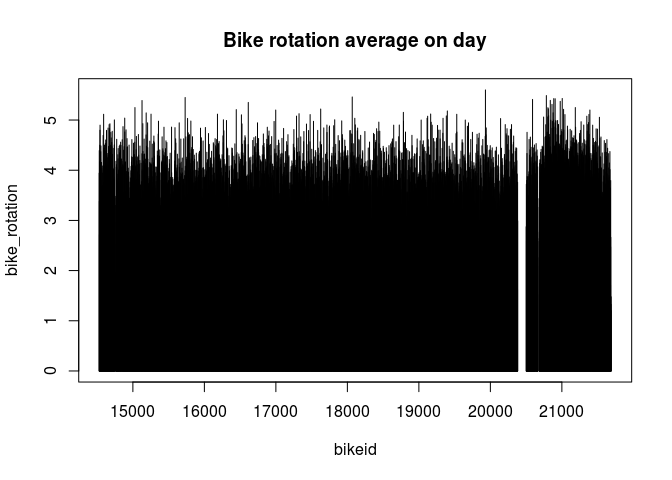

```r
# bike rotation average on day
dt_bike %>% group_by(bikeid) %>% summarise(bike_rotation=n()/365) %>%
  plot(type="h", main="Bike rotation average on day")
```

We can see each bike's usage by duration and distance, may be helpful for maintenance.

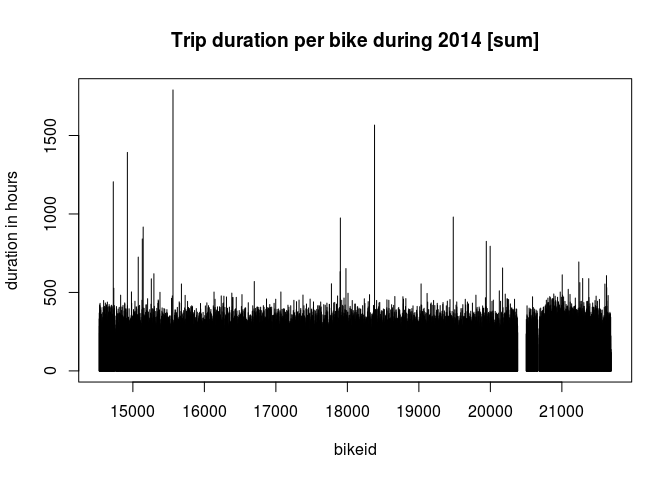

```r
# bike duration
dt_bike %>% group_by(bikeid) %>%
  summarise(sum_duration=sum(tripduration)/60/60) %>%
  arrange(desc(sum_duration)) %>%
  plot(type="h", main="Trip duration per bike during 2014 [sum]", ylab="duration in hours")
```

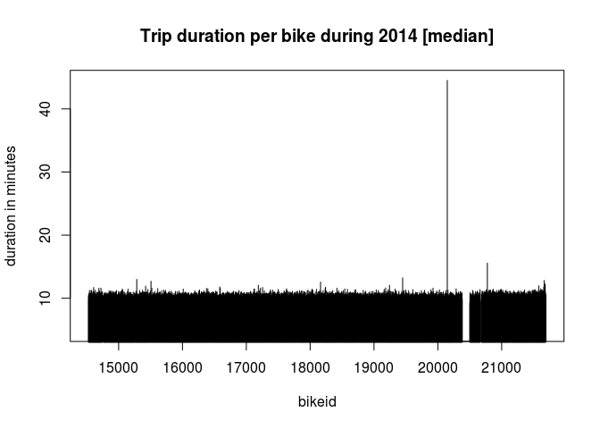

```r
# dt_bike %>% group_by(bikeid) %>% summarise(sum_duration=mean(tripduration)/60) %>% arrange(desc(sum_duration)) %>%
  # plot(type="h", main="Trip duration per bike during 2014 [mean]", ylab="duration in minutes")
dt_bike %>% group_by(bikeid) %>%
  summarise(sum_duration=median(tripduration)/60) %>%
  arrange(desc(sum_duration)) %>%
  plot(type="h", main="Trip duration per bike during 2014 [median]", ylab="duration in minutes")
```

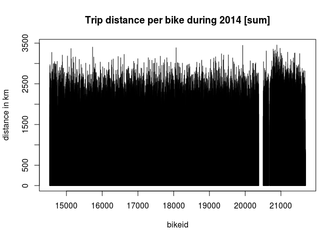

```r
# bike distance
dt_bike %>% group_by(bikeid) %>%
  summarise(sum_distance=sum(tripdistance)/1000) %>%
  arrange(desc(sum_distance)) %>%
  plot(type="h", main="Trip distance per bike during 2014 [sum]", ylab="distance in km")
```

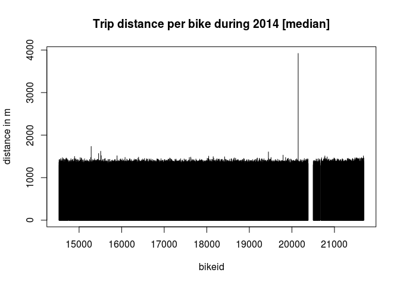

```r
# dt_bike %>% group_by(bikeid) %>% summarise(sum_distance=mean(tripdistance)) %>% arrange(desc(sum_distance)) %>%
#   plot(type="h", main="Trip distance per bike during 2014 [mean]", ylab="distance in m")
dt_bike %>% group_by(bikeid) %>%
  summarise(sum_distance=median(tripdistance)) %>%
  arrange(desc(sum_distance)) %>%
  plot(type="h", main="Trip distance per bike during 2014 [median]", ylab="distance in m")
```

## Station relationship

Here, we use graph try to see the relationship between each station. The most self-loop station, the most connected stations.

The fisrt parameter: - trip duration > 2min - 700 times in the year

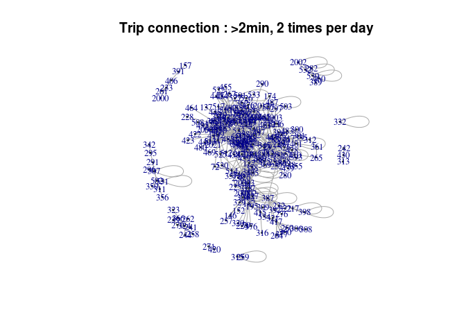

```r
# trip duration > 2min & fréquence 2 fois par jour
dt_graph <- dt_bike %>%
  group_by(start.station.id, end.station.id) %>%
  filter(tripduration>120) %>%
  summarise(count=n()) %>%
  filter(count>700)
bike_graph <- graph.data.frame((dt_graph[,1:2]))
plot(bike_graph, main="Trip connection : >2min, 2 times per day",
  vertex.size=0, vertex.label.cex=0.8, edge.arrow.size=0)
```

To avoid self-loop, we change the parameter: - trip distance > 100m - 700 times in the year

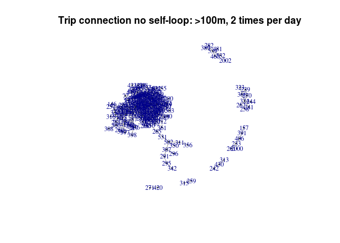

```r
## get rid of self loop
# distance > 100m & 2 fois par jour
dt_graph <- dt_bike %>% group_by(start.station.id, end.station.id) %>%
  filter(tripdistance>100) %>%
  summarise(count=n()) %>%
  filter(count>700)
bike_graph <- graph.data.frame((dt_graph[,1:2]))
plot(bike_graph, main="Trip connection no self-loop: >100m, 2 times per day",
  vertex.size=0, vertex.label.cex=0.8, edge.arrow.size=0, layout=layout.kamada.kawai)
```

## Trip in map

Here is how I made the map at the top of the post.

In order to make the map readable, we have filtered:

- trip duration > 2 mins
- frequency > 600 times per year
- and we show only the first 800 most frequent trips
- Note that the self-loop cannot be displayed

```r
## get coodinate of stations
dt_map <- dt_bike %>%
  group_by(start.station.id) %>%
  summarise(lat=first(start.station.latitude), lon=last(start.station.longitude))

## <2min 600times per year
dt_trip <- dt_bike %>%
  group_by(start.station.longitude, start.station.latitude, end.station.latitude, end.station.longitude) %>%
  filter(tripduration>120) %>%
  summarise(count=n()) %>%
  filter(count>600)
dt_trip <- dt_trip[order(dt_trip$count, decreasing = TRUE),]

# start of ploting
bike_trip <- leaflet() %>%
  addTiles('http://{s}.tile.openstreetmap.se/hydda/full/{z}/{x}/{y}.png') %>%
  setView(-74.0059, 40.71278, zoom=13) %>%
  addCircles(lat= ~ lat, lng = ~ lon, data=dt_map)

quantile(dt_trip$count)
dt_trip$count_cut <- cut(dt_trip$count, c(600, 900, 1200,Inf))
table(dt_trip$count_cut, as.numeric(dt_trip$count_cut))

library(RColorBrewer)
colors <- brewer.pal(max(as.numeric(dt_trip$count_cut)), "Set1")
# barplot(seq(1,3), col=colors)
## get 500 the most frequent trip
a_ply(dt_trip[1:800,], 1, function(x){
  bike_trip <<- bike_trip %>%
    addPolylines(lng= c(x$start.station.longitude, x$end.station.longitude),
      lat=c(x$start.station.latitude, x$end.station.latitude),
      color=colors[as.numeric(x$count_cut)], weight=as.numeric(x$count_cut))
})

bike_trip
```